# Dublin Data Science Workshop on the Statistical Analysis of Networks

Mick Cooney mickcooney@gmail.com

Monday, March 26 2018

# 1 Introduction to Network Data

All materials for this workshop is available in my standard GitHub repo:

https://github.com/kaybenleroll/dublin_r_workshops

[figure not shown]

book cover

The content of this workshop is based on the book “Statistical Analysis of Network Data with R” by Kolaczyk and Csardi. The data from this book is available from CRAN via the package `sand` and there is a GitHub repo for the code in the book also:

https://github.com/kolaczyk/sand

Additional ideas and elements and concepts were taken from the Coursera course “Social and Economic Networks” taught by Matthew O. Jackson

https://www.coursera.org/learn/social-economic-networks

## 1.1 Example Networks

In this workshop we are going to use three different networks as reference datasets to illustrate the concepts we discuss.

### 1.1.1 Florentine Marriage Data

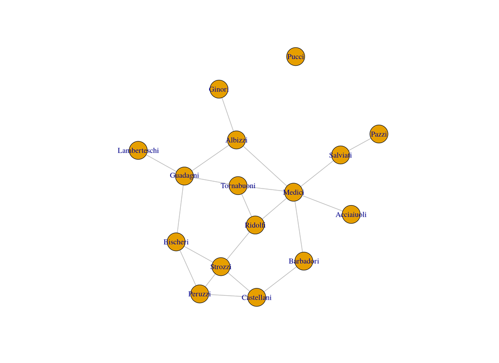

```r
data(flo, package = 'network')

florence_igraph <- graph_from_adjacency_matrix(flo, mode = 'undirected')

plot(florence_igraph)
```

We can use the package `ggnetwork` to allow us to plot networks within `ggplot2`

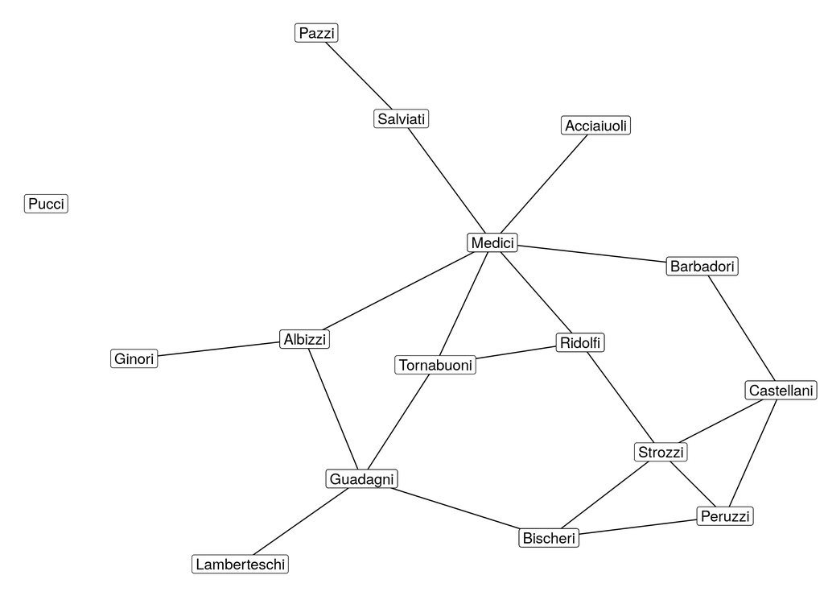

```r
ggplot(florence_igraph, aes(x = x, y = y, xend = xend, yend = yend)) +
    geom_edges() +
    geom_label(aes(label = vertex.names), size = 5) +
    theme_blank()
```

```r
### Show graph vertices
V(florence_igraph)
```

```
## + 16/16 vertices, named, from 66f5da4:
##  [1] Acciaiuoli   Albizzi      Barbadori    Bischeri     Castellani
##  [6] Ginori       Guadagni     Lamberteschi Medici       Pazzi
## [11] Peruzzi      Pucci        Ridolfi      Salviati     Strozzi
## [16] Tornabuoni
```

```r
### Show graph edges
E(florence_igraph)
```

```
## + 20/20 edges from 66f5da4 (vertex names):
##  [1] Acciaiuoli--Medici       Albizzi   --Ginori       Albizzi   --Guadagni
##  [4] Albizzi   --Medici       Barbadori --Castellani   Barbadori --Medici
##  [7] Bischeri  --Guadagni     Bischeri  --Peruzzi      Bischeri  --Strozzi
## [10] Castellani--Peruzzi      Castellani--Strozzi      Guadagni  --Lamberteschi
## [13] Guadagni  --Tornabuoni   Medici    --Ridolfi      Medici    --Salviati
## [16] Medici    --Tornabuoni   Pazzi     --Salviati     Peruzzi   --Strozzi
## [19] Ridolfi   --Strozzi      Ridolfi   --Tornabuoni
```

To help access the edgelist in a more usable form we convert the edgelist to a matrix, showing the origin and destination nodes.

```r
as_edgelist(florence_igraph)
```

```
##       [,1]         [,2]
##  [1,] "Acciaiuoli" "Medici"
##  [2,] "Albizzi"    "Ginori"
##  [3,] "Albizzi"    "Guadagni"
##  [4,] "Albizzi"    "Medici"
##  [5,] "Barbadori"  "Castellani"
##  [6,] "Barbadori"  "Medici"
##  [7,] "Bischeri"   "Guadagni"
##  [8,] "Bischeri"   "Peruzzi"
##  [9,] "Bischeri"   "Strozzi"
## [10,] "Castellani" "Peruzzi"
## [11,] "Castellani" "Strozzi"
## [12,] "Guadagni"   "Lamberteschi"
## [13,] "Guadagni"   "Tornabuoni"
## [14,] "Medici"     "Ridolfi"
## [15,] "Medici"     "Salviati"
## [16,] "Medici"     "Tornabuoni"
## [17,] "Pazzi"      "Salviati"
## [18,] "Peruzzi"    "Strozzi"
## [19,] "Ridolfi"    "Strozzi"
## [20,] "Ridolfi"    "Tornabuoni"
```

The elements of a graph can all have attributes:

```r
graph_attr_names(florence_igraph)
```

```
## character(0)
```

```r
vertex_attr_names(florence_igraph)
```

```
## [1] "name"
```

```r
edge_attr_names(florence_igraph)
```

```
## character(0)
```

Subgraphs are subsets of graphs that are part of the whole.

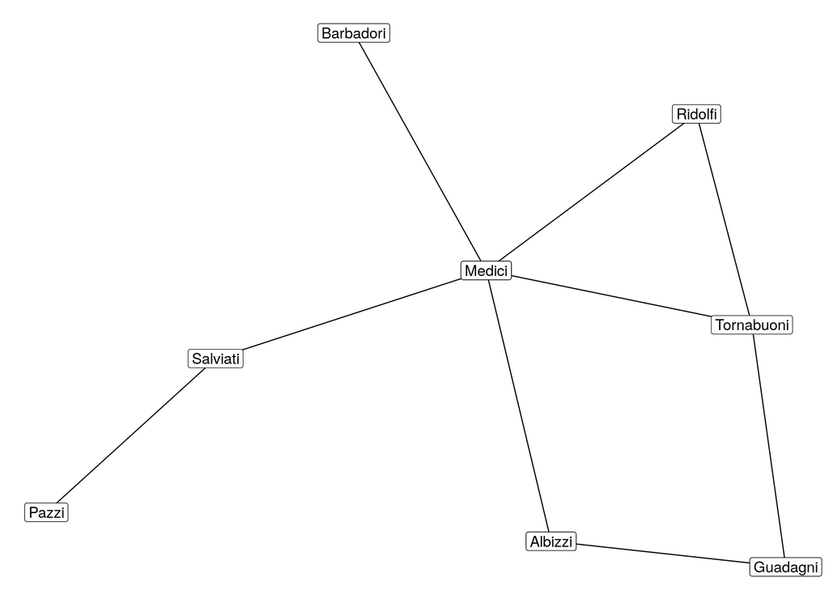

```r
family_keep <- c('Medici', 'Barbadori', 'Ridolfi','Tornabuoni','Pazzi'
                ,'Salviati', 'Albizzi', 'Guadagni')

florence_subgraph <- induced_subgraph(florence_igraph, family_keep)

ggplot(florence_subgraph, aes(x = x, y = y, xend = xend, yend = yend)) +
    geom_edges() +
    geom_label(aes(label = vertex.names), size = 5) +
    theme_blank()
```

### 1.1.2 US Airport Data

```r
data(USairports)


### Show graph vertices
V(USairports)
```

```
## + 755/755 vertices, named, from bf6202d:
##   [1] BGR BOS ANC JFK LAS MIA EWR BJC TEB LAX AEX BFI ELM GEG ICT PBI PIT SFO
##  [19] VCT IAD ABE AGS AVL AVP BDL BHM BNA BTR BUF BWI CAE CAK CHA CHO CHS CLE
##  [37] CLT CMH CRW CVG DAB DAY DCA DTW EWN FAY GNV GPT GSO GSP HPN HSV ILM IND
##  [55] JAN LEX LGA LIT MDT MGM MKE MLB MOB MSP MSY MYR OAJ ORF PGV PHF PHL PNS
##  [73] PWM RDU RIC ROA SAV SDF SRQ STL SYR TLH TRI TYS VPS XNA ALB BGM BTV ERI
##  [91] FLO HHH HTS HVN IPT ISP ITH LYH MHT PVD ROC SBY SCE SWF BFD DUJ EYW FKL
## [109] FLL JHW LWB MCO PKB TPA ACT AOO BHB BKW BPT CKB CLL DRT GRK IAH JST LCH
## [127] LFT MAF MGW MLU ORD PBG PQI SHD SHV TYR CID MCI MLI MSN OKC OMA SBN SGF
## [145] TUL GKN ABQ ATL AUS BKG DEN DFW HOU MDW PDX PHX PIE RSW SAN SAT SEA SLC
## [163] SMF SNA TUS ABY ACY BMI DSM FNT GLH GRR GTR JAX MEM SJU UTM GUM ROP SPN
## + ... omitted several vertices
```

```r
### Show graph edges
E(USairports)
```

```
## + 23473/23473 edges from bf6202d (vertex names):
##  [1] BGR->JFK BGR->JFK BOS->EWR ANC->JFK JFK->ANC LAS->LAX MIA->JFK EWR->ANC
##  [9] BJC->MIA MIA->BJC TEB->ANC JFK->LAX LAX->JFK LAX->SFO AEX->LAS BFI->SBA
## [17] ELM->PIT GEG->SUN ICT->PBI LAS->LAX LAS->PBI LAS->SFO LAX->LAS PBI->AEX
## [25] PBI->ICT PIT->VCT SFO->LAX VCT->DWH IAD->JFK ABE->CLT ABE->HPN AGS->CLT
## [33] AGS->CLT AVL->CLT AVL->CLT AVP->CLT AVP->PHL BDL->CLT BHM->CLT BHM->CLT
## [41] BNA->CLT BNA->CLT BNA->DCA BNA->PHL BTR->CLT BUF->CLT BUF->DCA BUF->PHL
## [49] BWI->PHL CAE->CLT CAE->CLT CAE->DCA CAK->CLT CAK->CLT CAK->DCA CAK->PHL
## [57] CHA->CLT CHA->DCA CHO->CLT CHS->CLT CHS->CLT CHS->DCA CLE->CLT CLE->CLT
## [65] CLE->PHL CLT->ABE CLT->AGS CLT->AGS CLT->AVL CLT->AVL CLT->AVP CLT->BDL
## [73] CLT->BHM CLT->BHM CLT->BNA CLT->BNA CLT->BTR CLT->BUF CLT->BWI CLT->CAE
## + ... omitted several edges
```

This is a much larger network, and visualising it is likely going to be a mess, but we will try anyway.

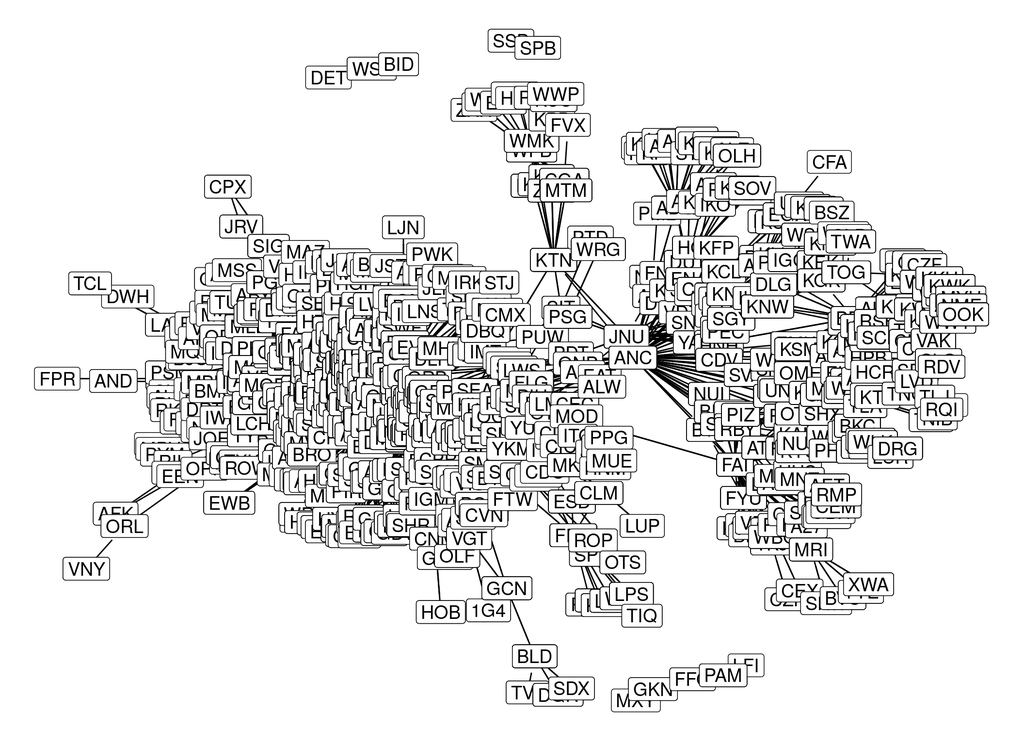

```r
ggplot(USairports, aes(x = x, y = y, xend = xend, yend = yend)) +
    geom_edges() +
    geom_label(aes(label = vertex.names), size = 5) +
    theme_blank()
```

Yeah, it is a mess.

We will try again with a small subgraph, using just 15 nodes

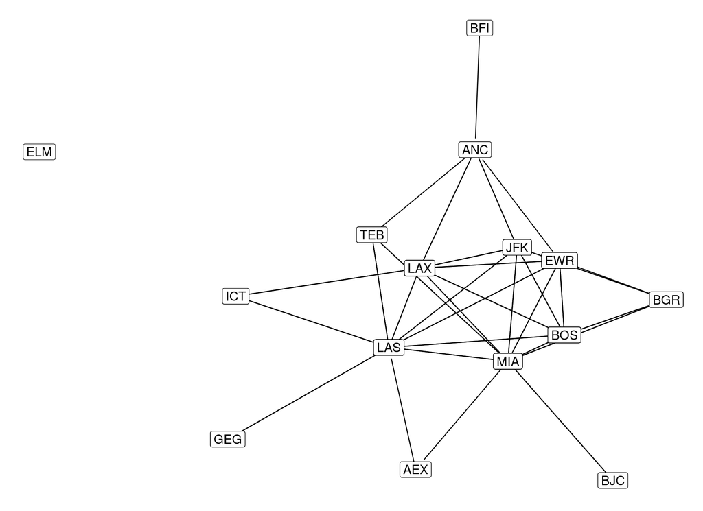

```r
usairport_subgraph <- induced_subgraph(USairports, 1:15)

ggplot(usairport_subgraph, aes(x = x, y = y, xend = xend, yend = yend)) +
    geom_edges() +
    geom_label(aes(label = vertex.names), size = 5) +
    theme_blank()
```

Now that we have seen this network, we look at what additional information is here.

```r
graph_attr_names(USairports)
```

```
## [1] "name"
```

```r
vertex_attr_names(USairports)
```

```
## [1] "name"     "City"     "Position"
```

```r
edge_attr_names(USairports)
```

```
## [1] "Carrier"    "Departures" "Seats"      "Passengers" "Aircraft"
## [6] "Distance"
```

We see that the edges in particular now have a number of attributes. We access them through `edge_attr()`

```r
edge_attr(USairports) %>%
    as_tibble()
```

```
## # A tibble: 23,473 x 6
##    Carrier                   Departures Seats Passengers Aircraft Distance
##    <chr>                          <dbl> <dbl>      <dbl>    <int>    <dbl>
##  1 British Airways Plc               1.  226.       193.      627     382.
##  2 British Airways Plc               1.  299.       253.      819     382.
##  3 British Airways Plc               1.  216.       141.      627     200.
##  4 China Airlines Ltd.              13. 5161.      3135.      819    3386.
##  5 China Airlines Ltd.              13. 5161.      4097.      819    3386.
##  6 Korean Air Lines Co. Ltd.        14. 3654.      1353.      627     236.
##  7 Lan Ecuador                       1.  204.       183.      626    1090.
##  8 Eva Airways Corporation          18. 5718.      4818.      627    3370.
##  9 G5 Executive Ag                   1.   14.         2.      667    1732.
## 10 G5 Executive Ag                   1.   14.         1.      667    1732.
## # ... with 23,463 more rows
```

### 1.1.3 Lazega Lawyers Network

```r
data(lazega)

lazega <- lazega %>% upgrade_graph()  # Data is in deprecated format.


### Show graph vertices
V(lazega)
```

```
## + 36/36 vertices, named, from 9e36dcc:
##  [1] V1  V2  V3  V4  V5  V6  V7  V8  V9  V10 V11 V12 V13 V14 V15 V16 V17 V18 V19
## [20] V20 V21 V22 V23 V24 V25 V26 V27 V28 V29 V30 V31 V32 V33 V34 V35 V36
```

```r
### Show graph edges
E(lazega)
```

```
## + 115/115 edges from 9e36dcc (vertex names):
##  [1] V1 --V17 V2 --V7  V2 --V16 V2 --V17 V2 --V22 V2 --V26 V2 --V29 V3 --V18
##  [9] V3 --V25 V3 --V28 V4 --V12 V4 --V17 V4 --V19 V4 --V20 V4 --V22 V4 --V26
## [17] V4 --V28 V4 --V29 V4 --V31 V5 --V18 V5 --V24 V5 --V28 V5 --V31 V5 --V32
## [25] V5 --V33 V6 --V24 V6 --V28 V6 --V30 V6 --V31 V6 --V32 V7 --V18 V9 --V12
## [33] V9 --V16 V9 --V29 V10--V24 V10--V26 V10--V29 V10--V31 V10--V34 V11--V17
## [41] V12--V15 V12--V16 V12--V17 V12--V19 V12--V26 V12--V29 V12--V34 V13--V31
## [49] V13--V33 V14--V16 V14--V17 V14--V25 V14--V28 V14--V30 V14--V32 V15--V16
## [57] V15--V19 V15--V20 V15--V22 V15--V24 V15--V26 V15--V29 V15--V32 V15--V35
## [65] V15--V36 V16--V17 V16--V22 V16--V26 V16--V27 V16--V29 V16--V32 V16--V34
## [73] V16--V36 V17--V19 V17--V22 V17--V24 V17--V25 V17--V26 V17--V28 V17--V29
## + ... omitted several edges
```

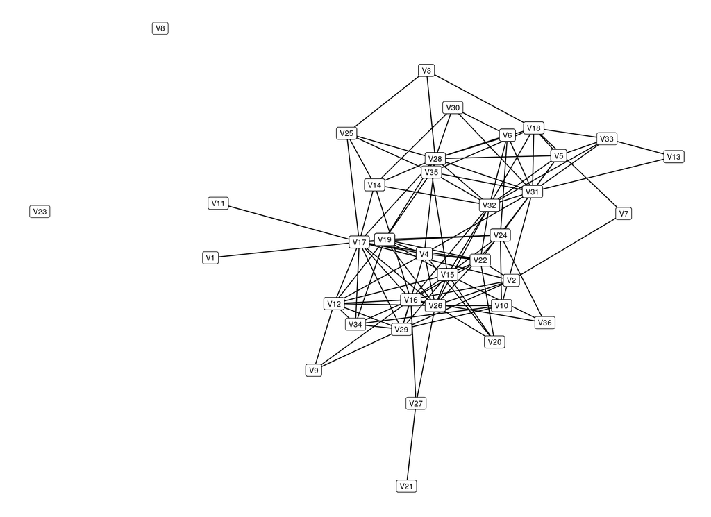

```r
ggplot(lazega, aes(x = x, y = y, xend = xend, yend = yend)) +
    geom_edges() +
    geom_label(aes(label = vertex.names), size = 3) +
    theme_blank()
```

```r
graph_attr_names(lazega)
```

```
## character(0)
```

```r
vertex_attr_names(lazega)
```

```
## [1] "name"      "Seniority" "Status"    "Gender"    "Office"    "Years"
## [7] "Age"       "Practice"  "School"
```

```r
edge_attr_names(lazega)
```

```
## character(0)
```

We see that the vertices have the attributes but the edges have none.

```r
vertex_attr(lazega) %>%
    as_tibble()
```

```
## # A tibble: 36 x 9
##    name  Seniority Status Gender Office Years   Age Practice School
##    <chr>     <int>  <int>  <int>  <int> <int> <int>    <int>  <int>
##  1 V1            1      1      1      1    31    64        1      1
##  2 V2            2      1      1      1    32    62        2      1
##  3 V3            3      1      1      2    13    67        1      1
##  4 V4            4      1      1      1    31    59        2      3
##  5 V5            5      1      1      2    31    59        1      2
##  6 V6            6      1      1      2    29    55        1      1
##  7 V7            7      1      1      2    29    63        2      3
##  8 V8            8      1      1      1    28    53        1      3
##  9 V9            9      1      1      1    25    53        2      1
## 10 V10          10      1      1      1    25    53        2      3
## # ... with 26 more rows
```

### 1.1.4 Exercises

1. Read in the network data contained in the file `NetScience.net`.
2. Visualise the network using both base `plot` and `ggplot2`.
3. Investigate the vertex and edge attributes.
4. Is this graph directed or undirected?
5. How many edges and vertices does it have?
6. Is it a simple graph?

## 1.2 Visualising Network Data

Plotting network data is not automatic - mathematical concepts allow us to convert network topology into a form amenable to plotting.

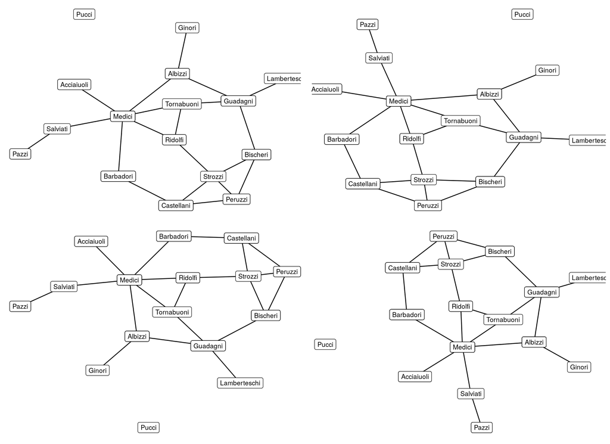

```r
plot_1 <- ggplot(florence_igraph, aes(x = x, y = y, xend = xend, yend = yend)) +
    geom_edges() +
    geom_label(aes(label = vertex.names), size = 3) +
    theme_blank()

plot_2 <- ggplot(florence_igraph, aes(x = x, y = y, xend = xend, yend = yend)) +
    geom_edges() +
    geom_label(aes(label = vertex.names), size = 3) +
    theme_blank()

plot_3 <- ggplot(florence_igraph, aes(x = x, y = y, xend = xend, yend = yend)) +
    geom_edges() +
    geom_label(aes(label = vertex.names), size = 3) +
    theme_blank()

plot_4 <- ggplot(florence_igraph, aes(x = x, y = y, xend = xend, yend = yend)) +
    geom_edges() +
    geom_label(aes(label = vertex.names), size = 3) +
    theme_blank()


plot_grid(plot_1, plot_2, plot_3, plot_4, ncol = 2)
```

### 1.2.1 Creating Layouts

To plot graphs visually, we need a way to transform the graphs into 2D coordinates. A number of layout algorithms exist.

To show the differences, we plot the Florentine network using a number of different layout algorithms.

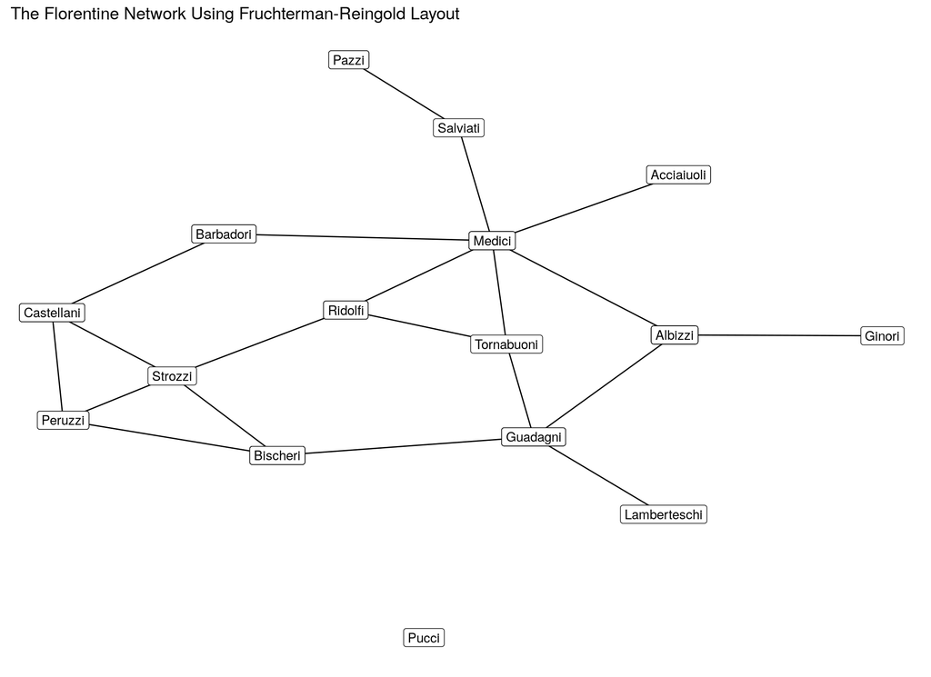

```r
ggplot(ggnetwork(florence_igraph, layout = 'fruchtermanreingold')
      ,aes(x = x, y = y, xend = xend, yend = yend)) +
    geom_edges() +
    geom_label(aes(label = vertex.names)) +
    ggtitle('The Florentine Network Using Fruchterman-Reingold Layout') +
    theme_blank()
```

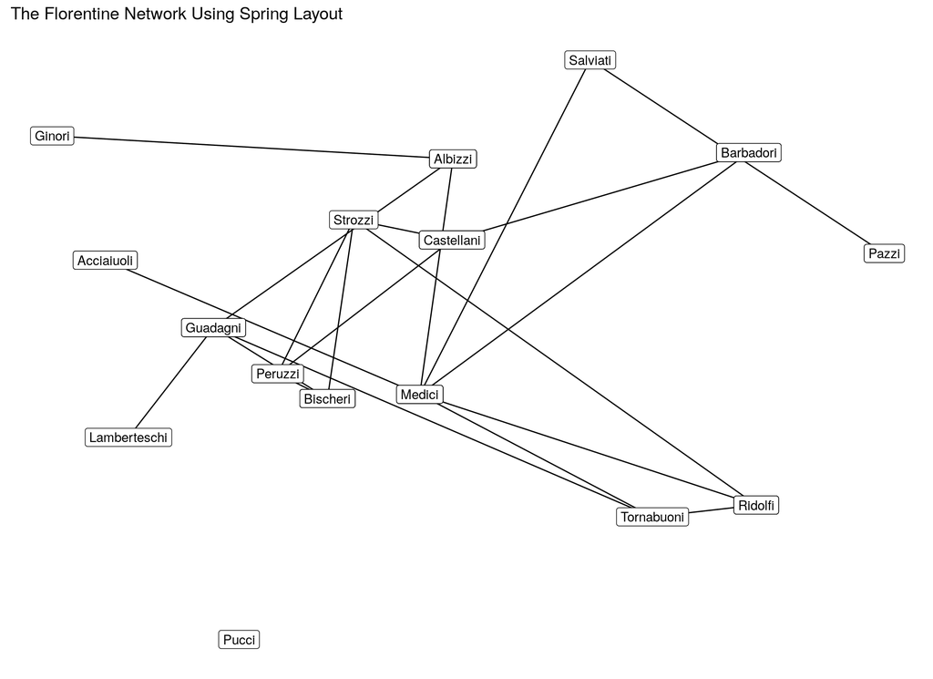

```r
ggplot(ggnetwork(florence_igraph, layout = 'spring')
      ,aes(x = x, y = y, xend = xend, yend = yend)) +
    geom_edges() +
    geom_label(aes(label = vertex.names)) +
    ggtitle('The Florentine Network Using Spring Layout') +
    theme_blank()
```

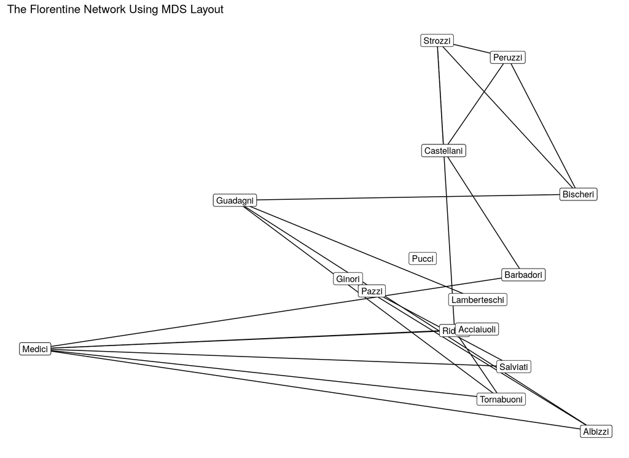

```r
ggplot(ggnetwork(florence_igraph, layout = 'mds')
      ,aes(x = x, y = y, xend = xend, yend = yend)) +
    geom_edges() +
    geom_label(aes(label = vertex.names)) +
    ggtitle('The Florentine Network Using MDS Layout') +
    theme_blank()
```

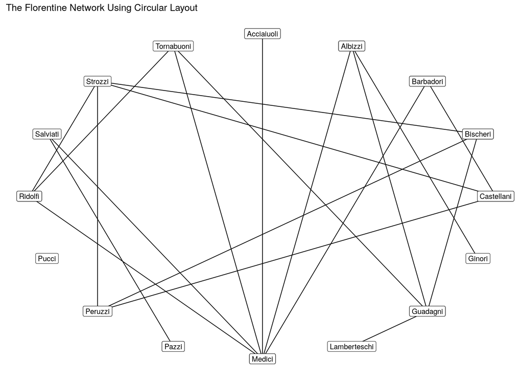

```r
ggplot(ggnetwork(florence_igraph, layout = 'circle')
      ,aes(x = x, y = y, xend = xend, yend = yend)) +
    geom_edges() +
    geom_label(aes(label = vertex.names)) +
    ggtitle('The Florentine Network Using Circular Layout') +
    theme_blank()
```

We save the FR layout for future plotting so that all plots looks the same

```r
florentine_fr_layout <- ggnetwork(florence_igraph, 'fruchtermanreingold')
```

### 1.2.2 Exercises

1. Produce similar visualisations as appropriate for the other graphs.
2. Investigate alternative layout algorithms for the Florentine network.
3. Try those layouts on the other network data.

# 2 Network Statistics

## 2.1 Network Degree

### 2.1.1 Degree of Vertex

The *degree* of a vertex is the count of connections from that vertex.

We now look at the distribution of vertex degree for the Florentine network:

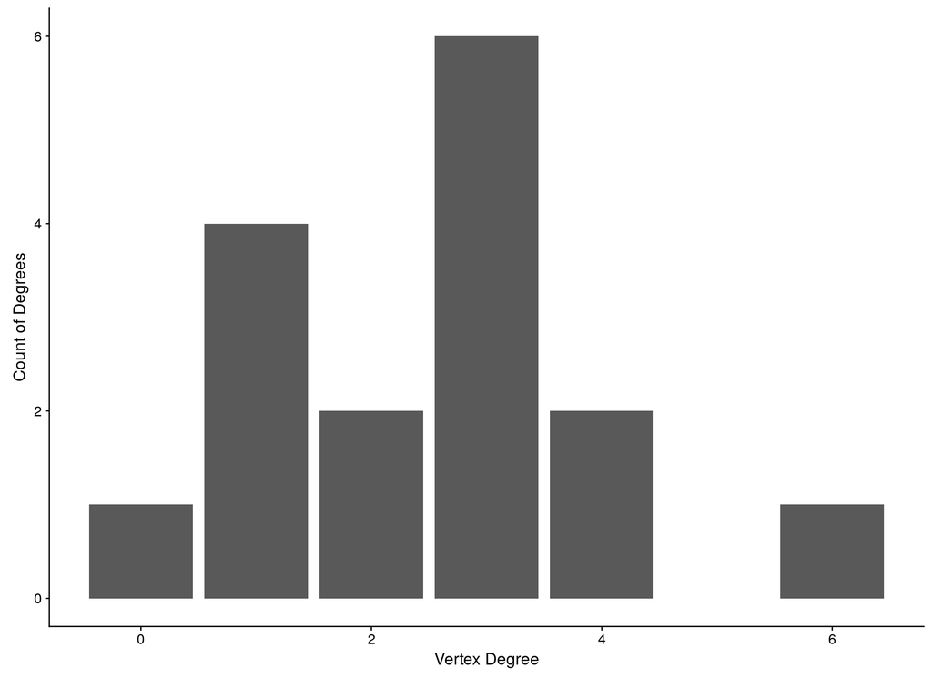

```r
ggplot() +
    geom_bar(aes(x = igraph::degree(florence_igraph))) +
    xlab("Vertex Degree") +
    ylab("Count of Degrees")
```

### 2.1.2 Average Neighbour Degree

Another interesting quantity is the average degree of all the neighbours of each vertex.

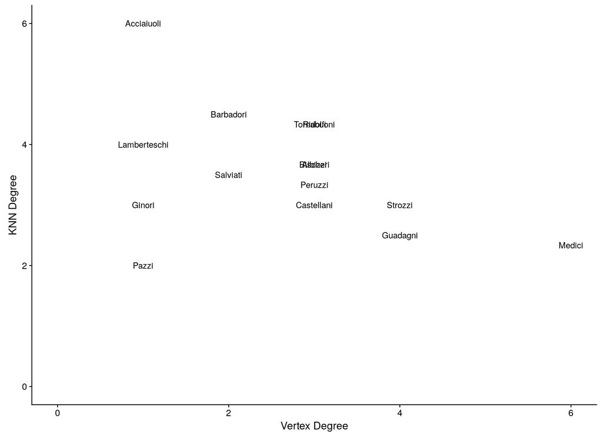

```r
flor_knn <- knn(florence_igraph)$knn

flor_knn_tbl <- data_frame(family = names(flor_knn)
                          ,degree = igraph::degree(florence_igraph)
                          ,knn    = flor_knn
                           )


ggplot(flor_knn_tbl) +
    geom_text(aes(x = degree, y = knn, label = family)) +
    expand_limits(y = 0) +
    xlab("Vertex Degree") +
    ylab("KNN Degree")
```

### 2.1.3 Exercises

1. Produce the degree distribution for the other networks
2. Calaculate the average neighbour degree distribution for the other networks
3. What can we infer about the importance of a vertex from these values?

## 2.2 Measures of Centrality

### 2.2.1 Between-ness Centrality

Between-ness measures how often a vertex comes between two other vertices in the graph.

$$c_B(\nu) = \sum_{s \neq t \neq \nu \in V} \frac{\sigma(s, t | \nu)}{\sigma(s,t)}$$

where $\sigma(s, t| \nu)$ is the count of shortest paths between $s$ and $t$ that goes through $\nu$ and $\sigma(s, t)$ is the total number of shortest paths between $s$ and $t$.

We now calculate the between-ness centrality for each vertex in the Florence marriage network

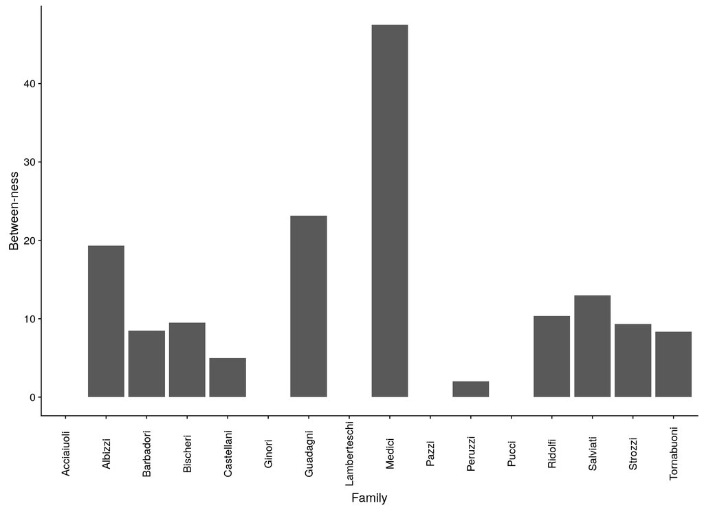

```r
florence_betweenness <- florence_igraph %>%
    (igraph::betweenness)() %>%
    sort(decreasing = TRUE)

ggplot() +
    geom_col(aes(x = names(florence_betweenness), y = florence_betweenness)) +
    xlab("Family") +
    ylab("Between-ness") +
    theme(axis.text.x = element_text(angle = 90, vjust = 0.5))
```

### 2.2.2 Closeness Centrality

Closeness centrality is measure of the distance of the vertex from other vertices in the graph.

$$c_{Cl}(\nu) = \frac{1}{\sum_{u \in V} \text{dist}(u, \nu)}$$

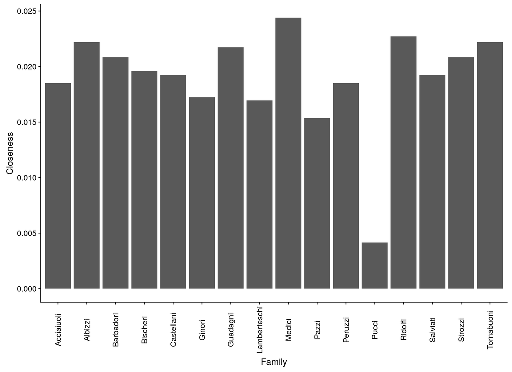

```r
florence_closeness <- florence_igraph %>%
    (igraph::closeness)() %>%
    sort(decreasing = TRUE)

ggplot() +
    geom_col(aes(x = names(florence_closeness), y = florence_closeness)) +
    xlab("Family") +
    ylab("Closeness") +
    theme(axis.text.x = element_text(angle = 90, vjust = 0.5))
```

### 2.2.3 Eigenvector Centrality

Eigenvector centrality is a class of centrality measures based on linear systems derived from the graph.

The most common of these are the eigenvectors of the adjacency matrix produced from the graph.

The key idea here is that vertices which are ‘central’ in the network are so due to their neighbours being ‘central’. This concept is inherently implicit in nature and so is calculated via linear algebra means.

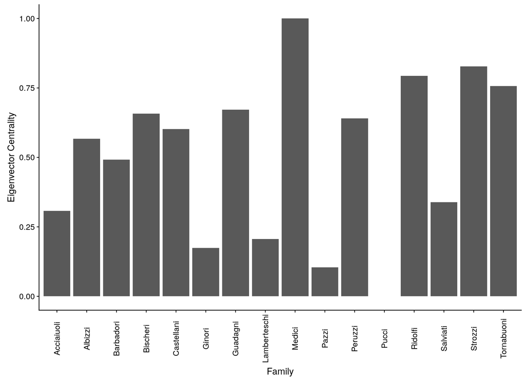

```r
florence_eigencent <- florence_igraph %>%
    eigen_centrality() %>%
    .$vector %>%
    sort(decreasing = TRUE)

ggplot() +
    geom_col(aes(x = names(florence_eigencent), y = florence_eigencent)) +
    xlab("Family") +
    ylab("Eigenvector Centrality") +
    theme(axis.text.x = element_text(angle = 90, vjust = 0.5))
```

### 2.2.4 Exercises

1. Calculate the centrality measures for the other networks

## 2.3 Network Cohesion

### 2.3.1 Cliques

A *clique* is a ‘maximally-connected subgraph’, that is, it is a subset of the nodes of the graph that are all connected to one another.

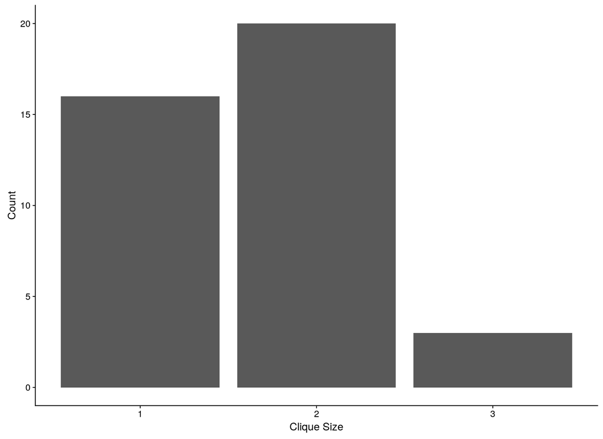

```r
clique_size <- florence_igraph %>%
    cliques %>%
    map_int(length)

ggplot() +
    geom_bar(aes(x = clique_size)) +
    xlab("Clique Size") +
    ylab("Count")
```

### 2.3.2 Clustering Co-efficient / Transitivity

The transitivity of the network is a measure of the ‘density’ of connections in the network. It is the ratio of triangles in the network to possible triangles.

Local transitivity does the same for all triangles contain the vertex.

```r
florence_igraph %>%
    transitivity()
```

```
## [1] 0.191489
```

```r
florence_igraph %>%
    transitivity(type = 'local', vids = c('Strozzi', 'Guadagni', 'Medici'))
```

```
## [1] 0.3333333 0.0000000 0.0666667
```

### 2.3.3 Shortest Paths

The shortest path measures are measures of the size and connectivity of the graph

```r
florence_igraph %>% mean_distance()
```

```
## [1] 2.48571
```

```r
florence_igraph %>% diameter()
```

```
## [1] 5
```

## 2.4 Graph Partitioning

### 2.4.1 Hierarchical Partitioning

```r
florence_partition <- cluster_fast_greedy(florence_igraph)

florence_partition %>% print
```

```
## IGRAPH clustering fast greedy, groups: 4, mod: 0.4
## + groups:
##   $`1`
##   [1] "Acciaiuoli" "Medici"     "Pazzi"      "Ridolfi"    "Salviati"
##   [6] "Tornabuoni"
##
##   $`2`
##   [1] "Albizzi"      "Ginori"       "Guadagni"     "Lamberteschi"
##
##   $`3`
##   [1] "Barbadori"  "Bischeri"   "Castellani" "Peruzzi"    "Strozzi"
##
##   + ... omitted several groups/vertices
```

```r
florence_partition %>% str()
```

[output not shown]

We can now replot the network but colour each of the nodes by their cluster membership.

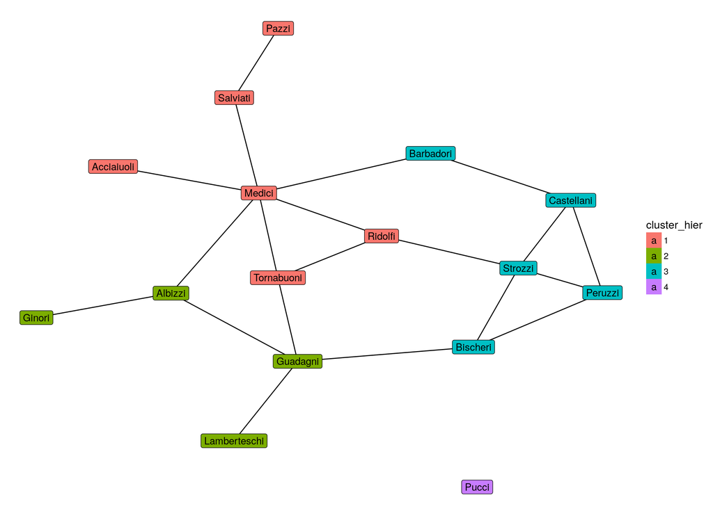

```r
hier_label_tbl <- data_frame(
    vertex.names = V(florence_igraph) %>% names()
   ,cluster_hier = florence_partition %>% membership() %>% as.character()
)

florentine_plot_layout <- florentine_fr_layout %>%
    merge(hier_label_tbl, by = 'vertex.names')

cluster_hier_plot <- ggplot(florentine_plot_layout
                           ,aes(x = x, y = y, xend = xend, yend = yend)) +
    geom_edges() +
    geom_nodelabel(aes(label = vertex.names, fill = cluster_hier)) +
    theme_blank()

cluster_hier_plot %>% plot()
```

### 2.4.2 Spectral Partitioning

We can use more direct linear algebra routines to partition the graph. To do this we construct the ‘graph Laplacian’ from the degrees of each vertex and its adjacency matrix.

$$\mathbf{L} = \mathbf{D} - \mathbf{A}$$

By analysing the eigenvalues and eigenvectors of this matrix, and recursively applying splits to the graphs based on the size of the eigenvalues, we break this network into pieces.

```r
florency_laplacian <- laplacian_matrix(florence_igraph)

flor_laplac_eigen <- eigen(florency_laplacian)

flor_laplac_eigen %>% print(digits = 2)
```

```
## eigen() decomposition
## $values
##  [1]  7.3e+00  5.5e+00  5.3e+00  4.3e+00  3.6e+00  3.4e+00  2.6e+00  2.5e+00
##  [9]  1.6e+00  1.5e+00  8.0e-01  7.0e-01  5.3e-01  3.5e-01  2.3e-16 -1.1e-16
##
## $vectors
##          [,1]   [,2]   [,3]     [,4]     [,5]     [,6]     [,7]   [,8]     [,9]
##  [1,] -0.1385  0.047 -0.016  4.3e-02  3.1e-02 -0.01724 -3.0e-03  0.068  3.4e-01
##  [2,] -0.2507 -0.177  0.152 -1.1e-01 -3.2e-01  0.59726  4.2e-01 -0.165 -5.2e-02
##  [3,] -0.1701  0.137  0.048 -1.6e-01 -1.4e-01 -0.33473  2.3e-01  0.043 -6.6e-01
##  [4,] -0.0502 -0.462 -0.043  1.8e-01 -1.8e-01 -0.51241  3.3e-01 -0.181  3.8e-01
##  [5,]  0.0275 -0.271 -0.229  5.0e-01  3.1e-01  0.41426 -1.5e-01  0.082 -9.5e-02
##  [6,]  0.0400  0.039 -0.035  3.4e-02  1.2e-01 -0.25317 -2.6e-01  0.108  9.1e-02
##  [7,]  0.1615  0.616 -0.389  2.5e-01  1.5e-01 -0.00196  4.1e-01 -0.084  2.5e-02
##  [8,] -0.0258 -0.137  0.090 -7.6e-02 -5.9e-02  0.00083 -2.5e-01  0.055 -4.4e-02
```

[output cut: 25 more lines]

We look at the eigenvalues ranked in order.

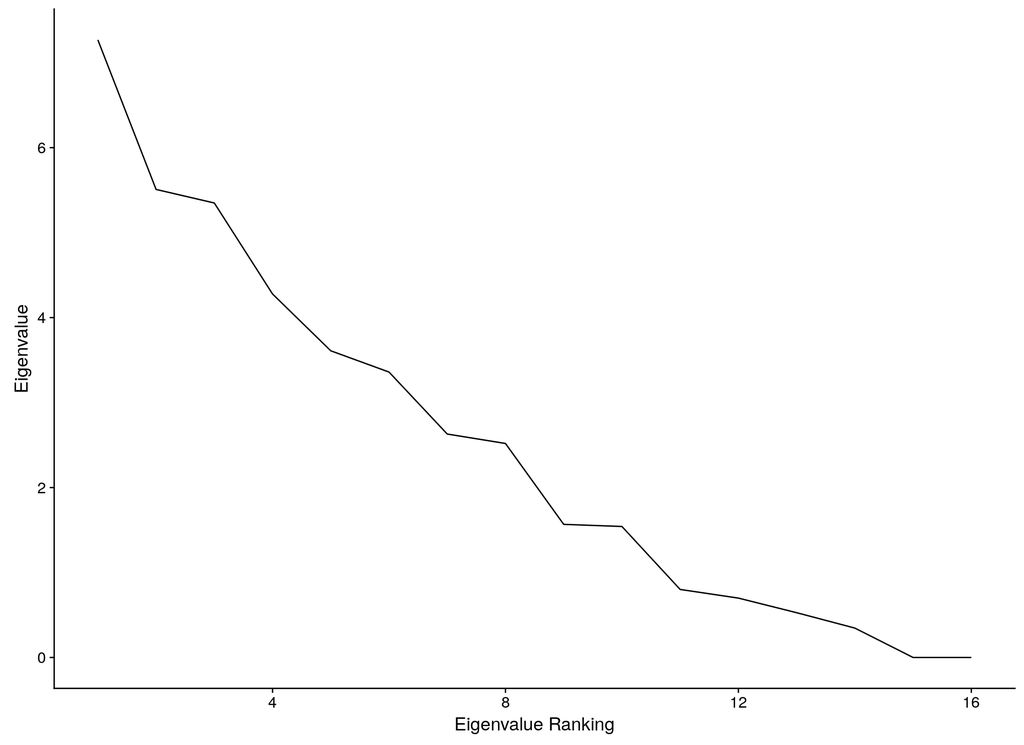

```r
ggplot() +
    geom_line(aes(x = seq_along(flor_laplac_eigen$values)
                 ,y = flor_laplac_eigen$values)) +
    expand_limits(y = 0) +
    xlab("Eigenvalue Ranking") +
    ylab("Eigenvalue")
```

We now cluster using these spectral methods

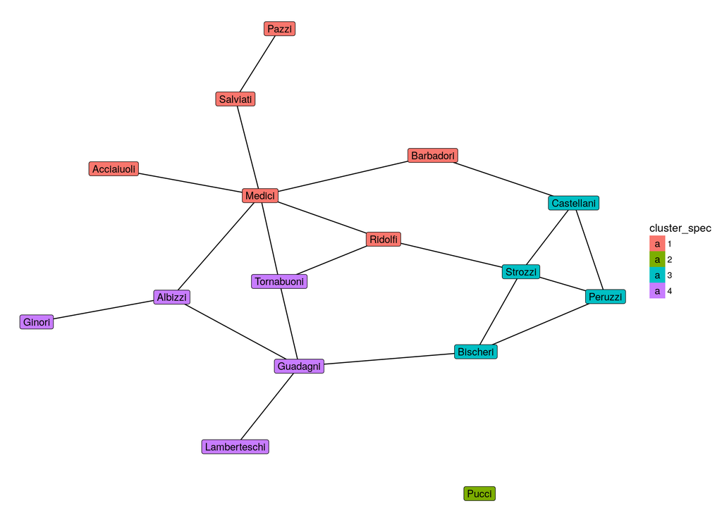

```r
florence_spec_partition <- florence_igraph %>%
    cluster_leading_eigen()

spec_label_tbl <- data_frame(
    vertex.names = V(florence_igraph) %>% names()
   ,cluster_spec = florence_spec_partition %>% membership() %>% as.character()
)

florentine_plot_layout <- florentine_fr_layout %>%
    merge(spec_label_tbl, by = 'vertex.names')

cluster_spec_plot <- ggplot(florentine_plot_layout
                           ,aes(x = x, y = y, xend = xend, yend = yend)) +
    geom_edges() +
    geom_nodelabel(aes(label = vertex.names, fill = cluster_spec)) +
    theme_blank()

cluster_spec_plot %>% plot()
```

We plot the two groupings beside each other to compare them.

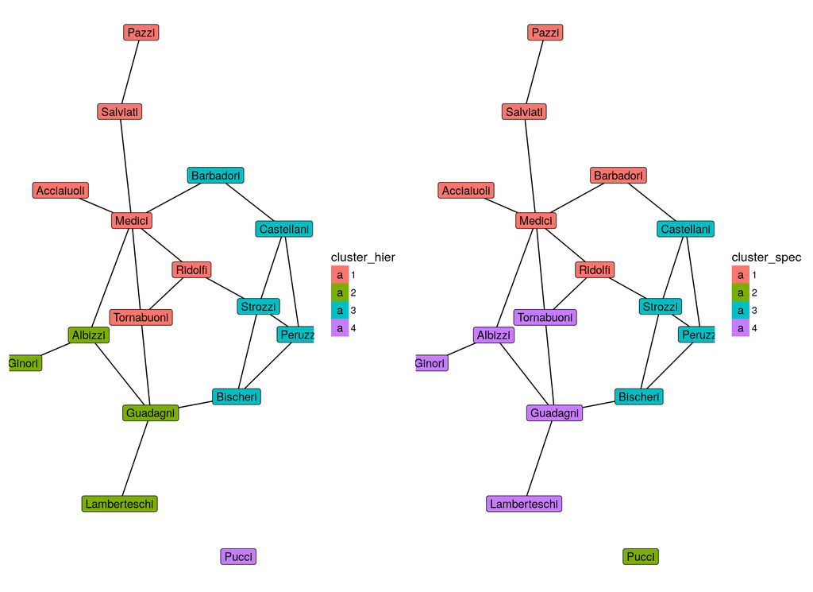

```r
plot_grid(cluster_hier_plot, cluster_spec_plot, ncol = 2)
```

### 2.4.3 Exercises

1. Run the clustering algorithms for the other network data.

## 2.5 Assortativity

*Assortativity* is a measure, analogous to correlation, that measures the tendency for nodes will similar properties to connect to one another.

The Florentine marriage data is a little unusual in that it does not contain any properties on the vertices or edges, but assortativity in degree can be calculated - measuring the tendency for high degree nodes to connect to one another)

```r
assortativity_degree(florence_igraph)
```

```
## [1] -0.374838
```

There are slightly different calculations for assortativity, depending on whether the attribute is numerical or categorical.

To test this, we will add the hierarchical clustering ID from the previous section to the Florentine graph and then measure the assortivity associated with that attribute.

```r
assortativity_nominal(florence_igraph, membership(florence_partition))
```

```
## [1] 0.614644
```

```r
assortativity_nominal(florence_igraph, membership(florence_spec_partition))
```

```
## [1] 0.548023
```

### 2.5.1 Exercises

1. Calculate the assortativity of membership for Florentine data as binary membership.
2. Calculate the assortativity for the other networks.

# 3 Random Graph Models

We now move on to modelling graph data using statistical methods.

To begin, we start with very simple generative processes for graphs, investigating how we can use these methods to approximate data we have.

## 3.1 Erdos-Renyi Graph Models

The simplest random graph model is one where we have a fixed number of nodes and have either a fixed count of edges with equally likely probability - the $G(n,m)$ model, or we assign each edge a fixed probability of occurring - the $G(n,p)$ model.

We start with the $G(n,m)$ model on a network with 50 nodes so that processing and visualisation is fast.

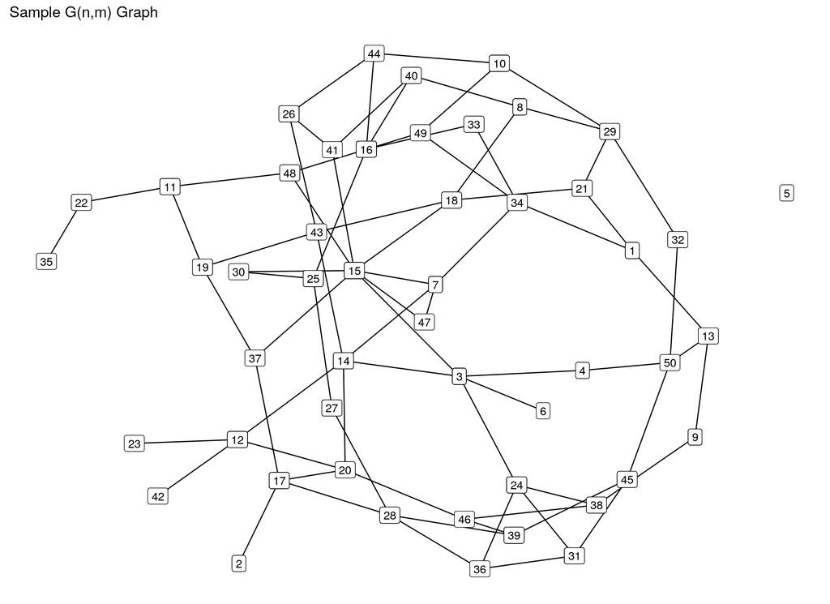

```r
gnmsample_igraph <- sample_gnm(50, 75)

ggplot(ggnetwork(gnmsample_igraph, layout = 'fruchtermanreingold')
      ,aes(x = x, y = y, xend = xend, yend = yend)) +
    geom_edges() +
    geom_label(aes(label = vertex.names)) +
    ggtitle('Sample G(n,m) Graph') +
    theme_blank()
```

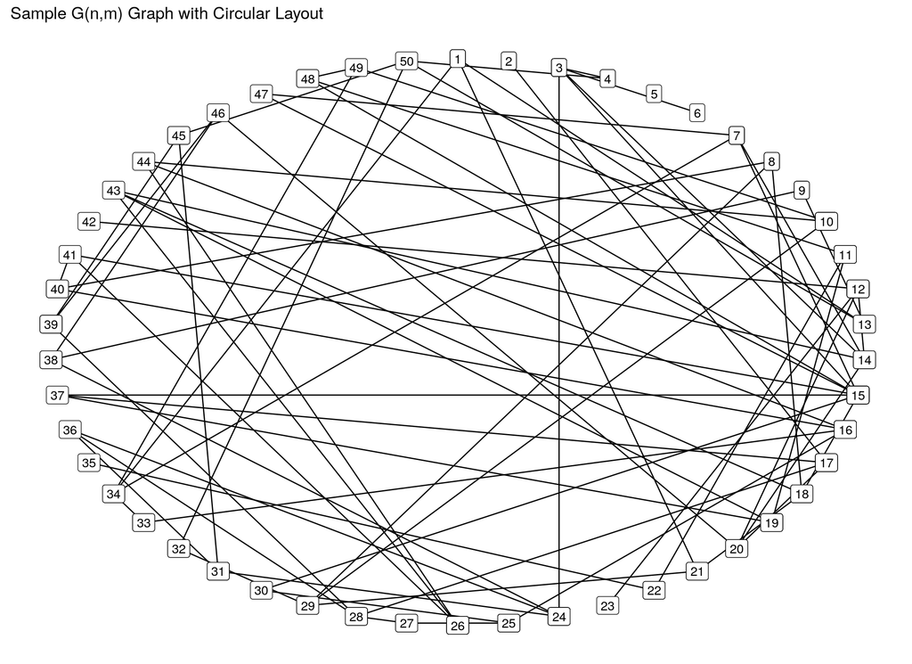

```r
ggplot(ggnetwork(gnmsample_igraph, layout = 'circle')
      ,aes(x = x, y = y, xend = xend, yend = yend)) +
    geom_edges() +
    geom_label(aes(label = vertex.names)) +
    ggtitle('Sample G(n,m) Graph with Circular Layout') +
    theme_blank()
```

Similarly, we generate a $G(n, p)$ graph.

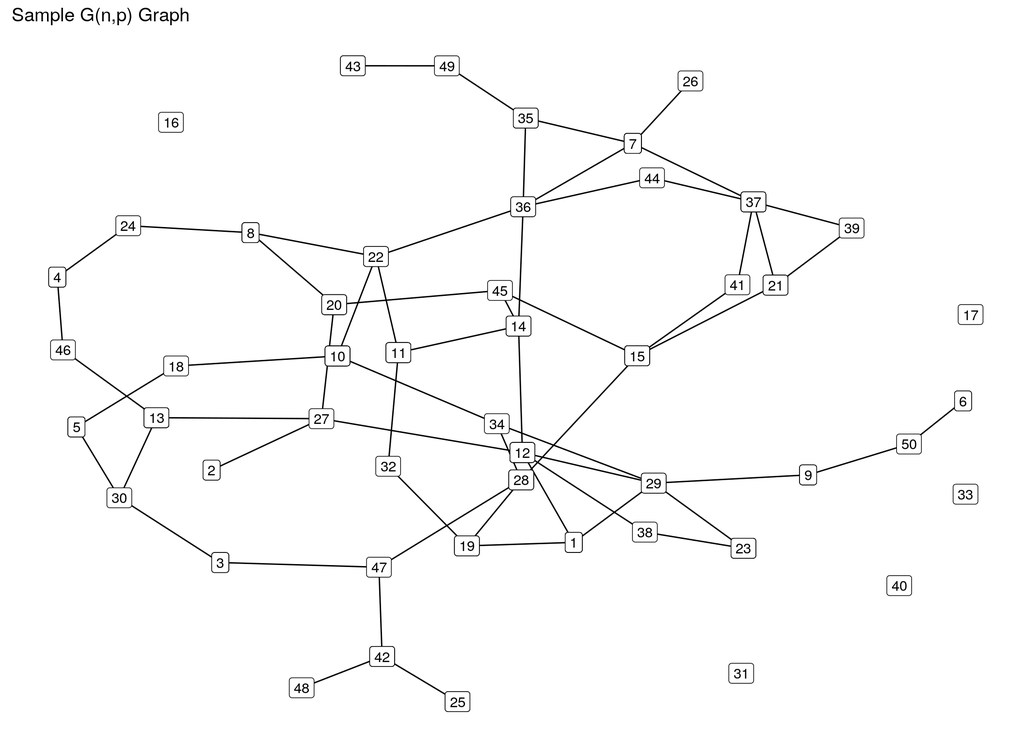

```r
gnpsample_igraph <- sample_gnp(50, 0.05)

ggplot(ggnetwork(gnpsample_igraph, layout = 'fruchtermanreingold')
      ,aes(x = x, y = y, xend = xend, yend = yend)) +
    geom_edges() +
    geom_label(aes(label = vertex.names)) +
    ggtitle('Sample G(n,p) Graph') +
    theme_blank()
```

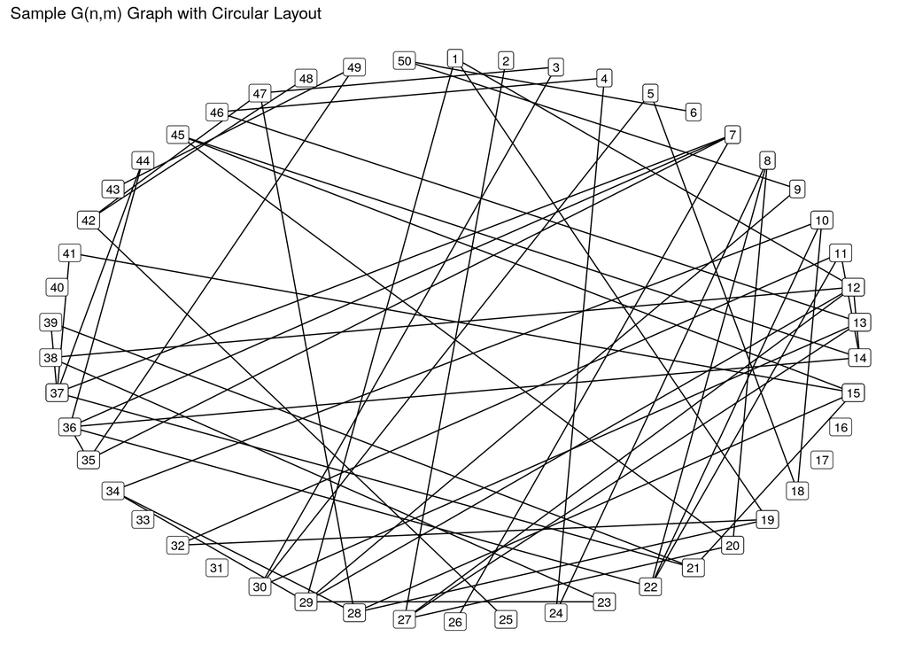

```r
ggplot(ggnetwork(gnpsample_igraph, layout = 'circle')
      ,aes(x = x, y = y, xend = xend, yend = yend)) +
    geom_edges() +
    geom_label(aes(label = vertex.names)) +
    ggtitle('Sample G(n,m) Graph with Circular Layout') +
    theme_blank()
```

## 3.2 Generalised Random Graph Models

## 3.3 Small World Models

## 3.4 Preferential Attachment Models

# 4 Statistical Models for Graphs